# SpaceRanger

Author

Will Gammerdinger, Noor Sohail, Zhu Zhuo, James Billingsley, Shannan Ho Sui

Published

July 22, 2025

# Learning Objectives

# SpaceRanger

Sequencing facilities often output scRNA-seq data, including spatial scRNA-seq data, in FASTQ format. Because this is Visium HD data from 10X Genomics, we used their proprietary pre-processing software [Space Ranger](https://www.10xgenomics.com/support/software/space-ranger/latest) to process the FASTQ files into a count matrix and other images. The `spaceranger count` command aligns the reads in the FASTQ files against a reference genome and provides their spatial location using the oligonucleotide barcode.

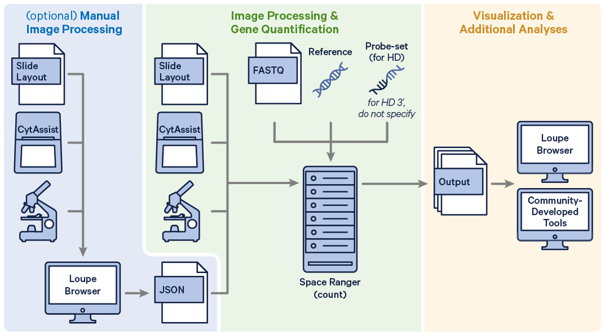

Overview of [10x SpaceRanger](https://www.10xgenomics.com/support/software/space-ranger/latest/analysis/running-pipelines/count-visium-hd) inputs and outputs

Before running the `count` pipeline in SpaceRanger, the following input files must be generated:

| Category | Item / File type | Description |
| --- | --- | --- |
| Reference files | Reference genome (FASTA + GTF) | Reference used for mapping reads (or) |
|  | Probe-set CSV | Probe definitions for probe-based assays |
| Sequencing data | FASTQ files | Reads from the sequencer for the sample |
| Area | Slide area (e.g., A1, B1) | Specifies which area on the slide to analyze |
| Images | CytAssist image (TIF) | Microscope image used for fiducial alignment and initial registration |
|  | Microscope image (BTF, optional) | Higher-quality image of the same tissue used for analysis |

These are all key input files that are necessary to the run the processing pipeline.

## Running SpaceRanger

Note that Space Ranger requires a Linux system with at least 32 cores, 64GB of RAM, and 1TB of disk space. It is not advisable to run this software on a local laptop or computer as the amount of computation power needed to large. Therefore, making use of cloud computing or a High Performance Compute Cluster would be the ideal environment to run the tool.

Here is example code for how you could run SpaceRanger:

```r
spaceranger count --id=hd_count \
   --transcriptome=/path/to/refdata-gex-GRCh38-2020-A \
   --fastqs=/path/to/fastq \
   --probe-set=/path/to/Visium_Human_Transcriptome_Probe_Set_v2.0_GRCh38-2020-A.csv \
   --slide=H1-YD7CDZK \
   --area=A1 \
   --cytaimage=/path/to/CAVG10539_2023-11-16_14-56-24_APPS115_H1-YD7CDZK_A1_S11088.tif \
   --image=/path/to/APPS115_11088_rescan_01.btf \
   --create-bam=false
```

## Outputs

When `spaceranger count` completes successfully, it will generate a variety of outputs (seen below), which will enable the analyst to perform further analysis in R/Python or using the proprietary Loupe browser from 10X Genomics.

[figure not shown]

[10x Space Ranger Documentation](https://www.10xgenomics.com/support/software/space-ranger/2.1/tutorials/count-cytassist-tma)

# SpaceRanger Steps

## Imaging Algorithms

- Identifying tissue regions
- Align tissue to the printed fiducial spot pattern

1. Tilt correction
2. Tissue detection
3. Image registration
4. UMI-based refinement
5. Cell segmentation
6. Fluroescence intensity

# Processing Tools for Other Technologies

SpaceRanger is the processing tool for 10x technologies, including methods such as Visium, VisiumHD, and Xenium. For other technologies, there are algorithms that have been generated for those results in mind. For example:

- STEREO-seq: [SAW](https://en.stomics.tech/products/stomics-software/stomics-offline-software/list.html)
- MERFISH: [Vizgen post processing tool](https://vizgen.github.io/vizgen-postprocessing/command_line_interface/index.html)
- Slide-seq: [WARP](https://broadinstitute.github.io/warp/docs/Pipelines/SlideSeq_Pipeline/README)